# Surrogate Splits

# Preamble

In this section and the following ones, we will look at methods to treat missingness and imbalance. In order to see how we are doing, we will also be looking at performance metrics. We begin with looking at surrogate splits.

# Introduction to Surrogate Splits

Surrogate splits are a method for tree-based methods to deal with missing data. The idea of **surrogate** splits is as the name suggests. The term `surrogate` means

```
Definitions from Oxford Languages: a substitute [...]. (Synonyms included: proxy, replacement, stand-in.)
```

Recall that in our case, we use univariate splits. So we find the splits on all variables $x_i$, and then choose the best split from those (computing “best” using only the complete cases). The problem is that if we choose a split involving a variable $x_m$, then we cannot split the data for which $x_m$ is missing. Surrogate splits provides a remedy for this.

In particular, surrogate splits work as follows. If some variables are missing and we cannot use the “primary” (best) split to split data at a node, we try to find the “next best” split that behaves most similarly to the split. We try to use the “next best” split. We keep trying the next “next best” split until we manage to split all the data at the node.

Breiman goes into further detail in [Chapter 5, 1] where he describes how we will find the split that “behaves most similarly” to the primary split. He defines a measure of similarity, and surrogate splits are then ranked according to that measure. Any observation missing on the split variable is then classified using the first surrogate split. If missing the surrogate variable, the second surrogate split is used, and so on.

This is similar to the process of replacing a missing value in a linear model by regressing on the non-missing values most highly correlated with it. However, Breiman notes that this algorithm for classification trees is more robust [Section 5.3.2, 1].

Surrogate splits are implemented natively in `rpart`, which we use below.

# Loading Data

We load the data using the code below.

```r
# Load necessary packages
library(rpart)
library(caret)  # For confusion matrix and precision/recall calculations
```

```r
library(pROC)   # For ROC curve
# Get the current working directory
current_dir <- getwd()
cat("Current directory:", current_dir, "\n")
```

```
## Current directory: C:/Users/megar/Documents/Code/Data Science Toolbox/dst-group-project-1/report
```

```r
# Get the parent directory
parent_dir <- dirname(current_dir)
cat("Parent directory:", parent_dir, "\n")
```

```
## Parent directory: C:/Users/megar/Documents/Code/Data Science Toolbox/dst-group-project-1
```

```r
# Set the working directory to the parent directory
setwd(parent_dir)
cat("New working directory:", getwd(), "\n")
```

```
## New working directory: C:/Users/megar/Documents/Code/Data Science Toolbox/dst-group-project-1
```

```r
# Load the training and test datasets
X_train <- read.csv("data/X_train.csv", row.names = 1)  # Set the first column as row names
y_train <- read.csv("data/y_train.csv", row.names = 1)  # Set the first column as row names
X_test <- read.csv("data/X_test.csv", row.names = 1)    # Set the first column as row names
y_test <- read.csv("data/y_test.csv", row.names = 1)    # Set the first column as row names

# Combine X_train and y_train into one data frame for rpart
train_data <- cbind(X_train, y_train)
```

# Model fitting

We fit the data using `rpart`. We can see the initial complexity parameter $\alpha$ (`cp`) to a low value (so almost no pruning occurs and we get a large tree). It will then use the weakest-link pruning we described before. In particular, as $\alpha$ increases, the tree which minimises the penalised loss function is constant until we find jump points. This occurs until we have pruned off everything and are left with the root node only. `rpart` intelligently does this for us, in a very user-friendly way.

Since `education` and `education_num` encode the same information, we drop the `education` column. (In fact, it did not make a big difference to the tree whether we include it or not – see the appendix.)

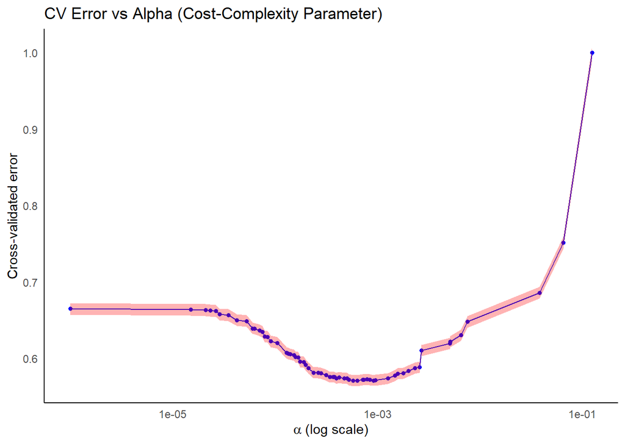

```r
# Load necessary libraries
library(ggplot2)
library(rpart)

# Drop the "education" column from the training data
train_data <- train_data[, !names(train_data) %in% "education"]

# Fit the classification tree using rpart with NA handling
fit <- rpart(income ~ ., data = train_data, method = "class", control = rpart.control(cp = 1e-6))

# Get the cost-complexity pruning table
cptable <- fit$cptable

# Create a dataframe from the cptable
data <- data.frame(CP = cptable[,"CP"],
                   xerror = cptable[,"xerror"],
                   xstd = cptable[,"xstd"])

# Create the plot using ggplot
ggplot(data, aes(x = CP, y = xerror)) +
  geom_line(color = "blue") +  # Line for xerror vs CP
  geom_point(color = "blue", size = 1.2) +  # Points on the line
  geom_ribbon(aes(ymin = xerror - xstd, ymax = xerror + xstd), fill = "red", alpha = 0.3) +  # Fill error band
  scale_x_log10() +  # Log scale for x-axis
  labs(title = "CV Error vs Alpha (Cost-Complexity Parameter)",
       x = expression(alpha ~ "(log scale)"),
       y = "Cross-validated error") +
  theme_minimal() +
  theme(
    panel.grid.major = element_blank(),  # Remove major gridlines
    panel.grid.minor = element_blank(),  # Remove minor gridlines
    axis.line = element_line(color = "black")  # Add x and y axis lines in black
  )
```

```r
cat("\nModel Complexity Parameters:\n")
```

```
##
## Model Complexity Parameters:
```

```r
printcp(fit)
```

```
##
## Classification tree:
## rpart(formula = income ~ ., data = train_data, method = "class",
##     control = rpart.control(cp = 1e-06))
##
## Variables actually used in tree construction:
##  [1] age            capital.gain   capital.loss   education.num  fnlwgt
##  [6] hours.per.week marital.status native.country occupation     race
## [11] relationship   sex            workclass
##
## Root node error: 9481/39774 = 0.23837
##
## n= 39774
##
##            CP nsplit rel error  xerror      xstd
```

[output cut: 63 more lines]

We can see that it finds discrete points (in blue) where the actual tree changes and a “weakest” branch is pruned off. Beyond $\alpha = 0.1$, there is no more pruning as we are just left with the root node. We can also have a look at the surrogate splits that were used.

```r
# Get surrogate splits information
surrogate_info <- fit$frame[fit$frame$var != "<leaf>", c("var", "n", "ncompete", "nsurrogate")]
surrogate_info <- surrogate_info[surrogate_info$nsurrogate > 0, ]  # Filter for nodes with surrogates

# Display the surrogate splits
cat("\nSurrogate Splits Information:\n")
```

```
##
## Surrogate Splits Information:
```

```r
print(head(surrogate_info))
```

```
##                var     n ncompete nsurrogate
## 1     relationship 39774        4          5
## 32      occupation 16482        4          2
## 64   education.num 13439        4          1
## 128            age 12458        4          5
## 515   capital.gain    30        4          4
## 129 marital.status   981        4          1
```

This is interpreted as follows:

- The `var` column represents the primary splitting variable for the node and `n` is the number of observations in that node.
- The `ncompete` is the number of competing splits available for that node. A competing split is an alternative variable or threshold that could have been chosen to split the node but wasn’t selected as the primary split. Essentially, it provides insight into other potential splits that the tree considered at that node.
- The `nsurrogate` indicates the number of surrogate splits available for the node.

The code filters for nodes with at least one surrogate split (surrogate_info$nsurrogate > 0), focusing on nodes where surrogate splitting is relevant.

We can identify the best value of $\alpha$ by using that value which minimises the cross-validated error.

```r
# Identify the best cp based on minimum xerror
best_cp <- cptable[which.min(cptable[,"xerror"]), "CP"]
cat("Best CP:", best_cp, "\n")
```

```
## Best CP: 0.0006328446
```

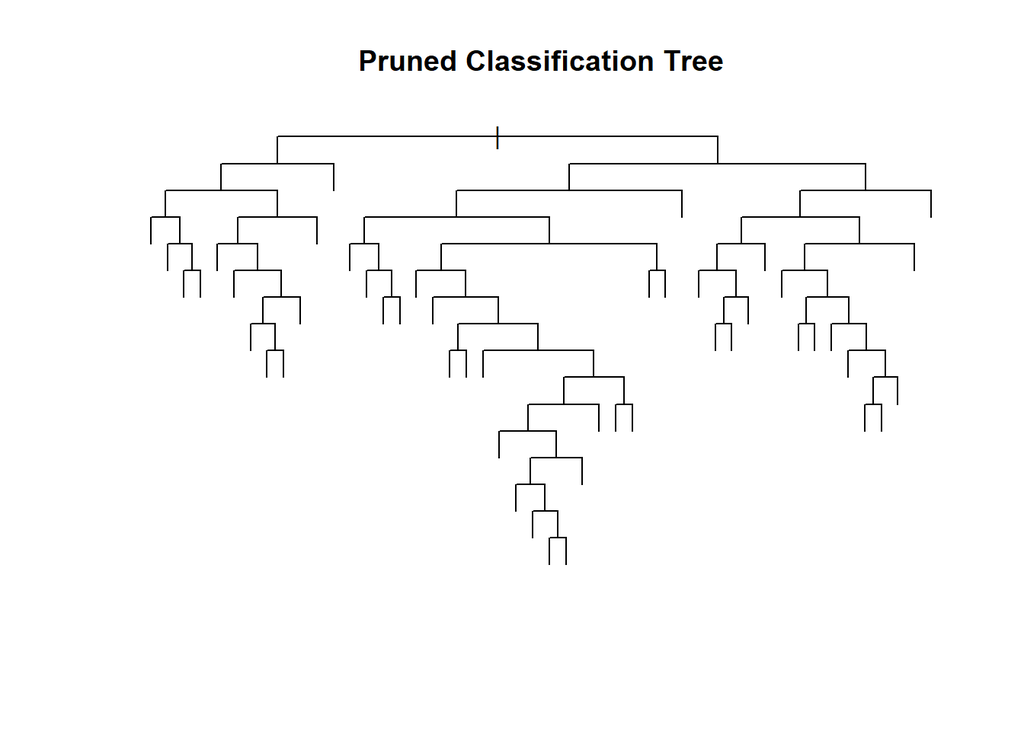

```r
# Prune the tree using the best cp
pruned_tree <- prune(fit, cp = best_cp)

# Plot the pruned tree
plot(pruned_tree, uniform = TRUE, main = "Pruned Classification Tree")
```

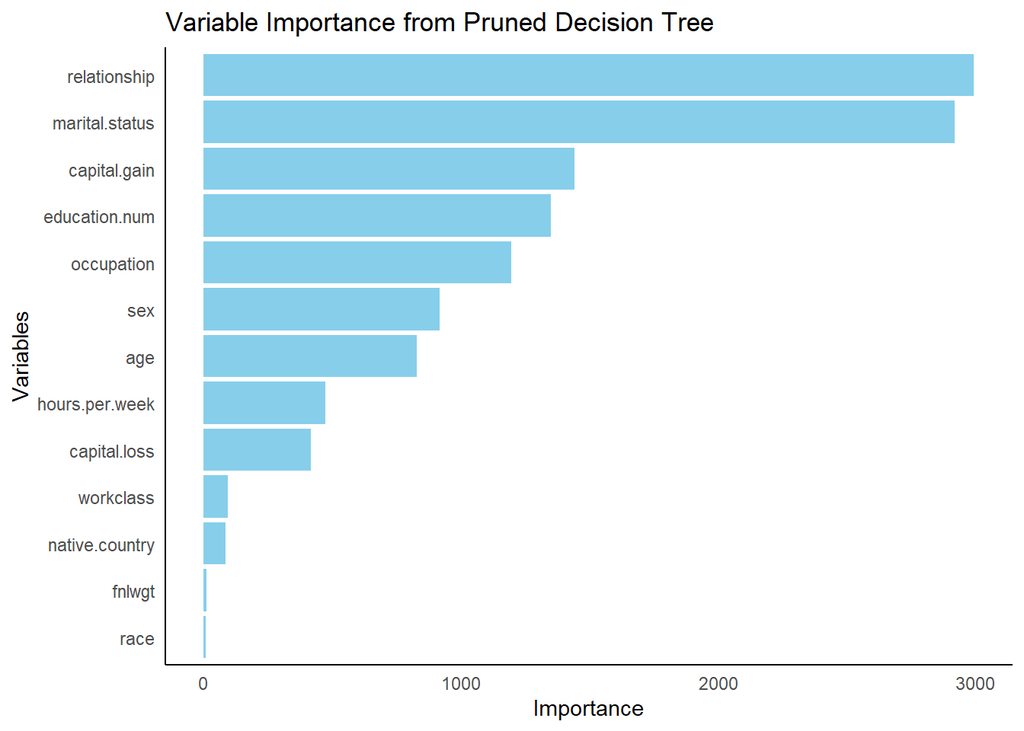

```r
# Load necessary libraries
library(ggplot2)
library(dplyr)  # For data manipulation
# Extract variable importance from the pruned tree
variable_importance <- data.frame(Variable = names(pruned_tree$variable.importance),
                                    Importance = pruned_tree$variable.importance)

# Sort the variable importance in descending order
variable_importance <- variable_importance %>%
  arrange(desc(Importance))

# Create a bar plot using ggplot
ggplot(variable_importance, aes(x = reorder(Variable, Importance), y = Importance)) +
  geom_bar(stat = "identity", fill = "skyblue") +  # Create bars
  coord_flip() +  # Flip coordinates for better readability
  labs(title = "Variable Importance from Pruned Decision Tree",
       x = "Variables",
       y = "Importance") +
  theme_minimal() +
  theme(
    panel.grid.major = element_blank(),  # Remove major gridlines
    panel.grid.minor = element_blank(),  # Remove minor gridlines
    axis.line = element_line(color = "black")  # Add x and y axis lines in black
  )
```

The results are expected from the EDA we did. In particular, relationship and marital status were closely related, so it makes sense that their importances are about the same. We can see that capital gain is much better at predicting income than capital loss. This again makes sense as we saw that the distributions of capital gain for each income class were markedly different, whereas the distributions of capital loss for each income class were not very different.

## Evaluation of Model

It is important to note that the data is imbalanced. Therefore, using accuracy as a performance metric can be misleading. We explore several metrics below and explore how the model performs.

### Confusion Matrix, Specificity, Sensitivity

The confusion matrix shows the predicted class against the actual class.

```r
# Make predictions on the test set
predictions <- predict(pruned_tree, newdata = X_test, type = "class")

# Load necessary libraries
library(caret)  # For confusionMatrix function
library(ggplot2)  # For plotting
library(reshape2)  # For reshaping the data

# Assuming 'predictions' and 'y_test' are defined
# Create a confusion matrix
confusion_mat <- confusionMatrix(as.factor(predictions), as.factor(y_test[,1]))

# Print confusion matrix statistics
print(confusion_mat)
```

```
## Confusion Matrix and Statistics
##
##           Reference
## Prediction <=50K >50K
##      <=50K  6507  921
##      >50K    355 1285
##
##                Accuracy : 0.8593
##                  95% CI : (0.852, 0.8664)
##     No Information Rate : 0.7567
##     P-Value [Acc > NIR] : < 2.2e-16
##
##                   Kappa : 0.5814
##
##  Mcnemar's Test P-Value : < 2.2e-16
##
##             Sensitivity : 0.9483
##             Specificity : 0.5825
##          Pos Pred Value : 0.8760
##          Neg Pred Value : 0.7835
##              Prevalence : 0.7567
##          Detection Rate : 0.7176
##    Detection Prevalence : 0.8191
##       Balanced Accuracy : 0.7654
##
##        'Positive' Class : <=50K
##
```

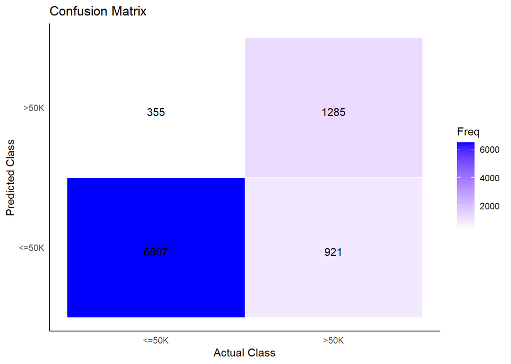

```r
# Extract the confusion matrix data for plotting
cm_table <- confusion_mat$table

# Convert the confusion matrix to a data frame for ggplot
cm_df <- as.data.frame(cm_table)

# Create a heatmap of the confusion matrix
ggplot(data = cm_df, aes(x = Reference, y = Prediction)) +
  geom_tile(aes(fill = Freq), color = "white") +  # Create tiles filled with frequency
  scale_fill_gradient(low = "white", high = "blue") +  # Color gradient from white to blue
  geom_text(aes(label = Freq), vjust = 1) +  # Add frequency text in the tiles
  labs(title = "Confusion Matrix", x = "Actual Class", y = "Predicted Class") +
  theme_minimal() +
  theme(
    panel.grid.major = element_blank(),  # Remove major gridlines
    panel.grid.minor = element_blank(),  # Remove minor gridlines
    axis.line = element_line(color = "black")  # Add x and y axis lines in black
  )
```

In summary, while the model demonstrates strong sensitivity and accuracy in predicting the positive class (<=50K), it struggles with specificity, leading to potential issues with false positives. Improvements could be made by adjusting the decision threshold or experimenting with different algorithms to enhance the model’s ability to accurately classify negative instances (>50K).

### ROC Curve, F1 Statistic

We next look at other measures called the precision, recall and the ROC curve.

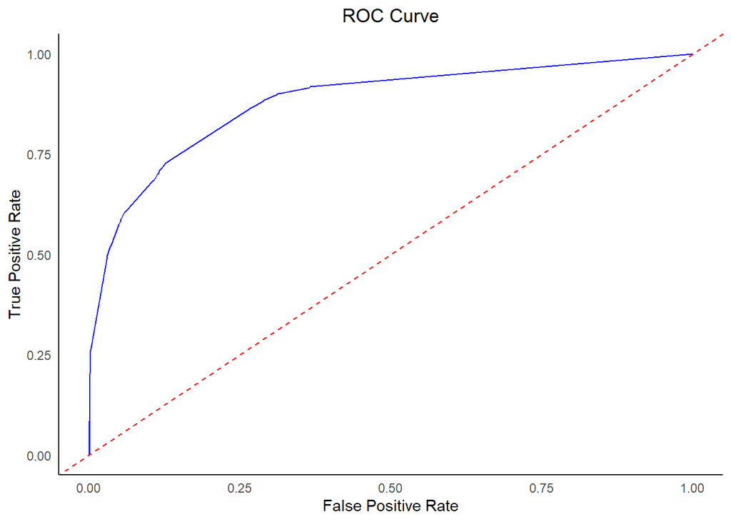

```r
# Load necessary libraries
library(caret)    # For precision and recall calculations
library(pROC)     # For ROC curve plotting
library(ggplot2)  # For ggplot2 plotting
library(dplyr)    # For data manipulation

# Convert predictions and actual values to factors
predictions_factor <- as.factor(predictions)
y_test_factor <- as.factor(y_test[, 1])  # Adjust as needed for the outcome variable

# Extract predicted probabilities for the positive class from the model=
pred_probs <- predict(pruned_tree, X_test, type = "prob")[, "<=50K"]  # Use the probabilities for the positive class

# Compute ROC curve using the predicted probabilities
roc_curve <- roc(y_test_factor, pred_probs, levels = c("<=50K", ">50K"))
# Create a data frame for ROC curve data
roc_data <- data.frame(
  FPR = 1 - roc_curve$specificities,  # False Positive Rate
  TPR = roc_curve$sensitivities         # True Positive Rate
)

# Plot ROC curve
ggplot(roc_data, aes(x = FPR, y = TPR)) +
  geom_line(color = "blue") +           # ROC curve
  geom_abline(slope = 1, intercept = 0, linetype = "dashed", color = "red") +  # Diagonal line
  labs(title = "ROC Curve",
       x = "False Positive Rate",
       y = "True Positive Rate") +
  theme_minimal() +
  theme(
    plot.title = element_text(hjust = 0.5),  # Center the title
    panel.grid.major = element_blank(),        # Remove major gridlines
    panel.grid.minor = element_blank(),        # Remove minor gridlines
    axis.line = element_line(color = "black")  # Add x and y axis lines in black
  ) +
  xlim(0, 1) +  # Set x-axis limits
  ylim(0, 1)    # Set y-axis limits
```

```r
# Calculate the AUC
auc_value <- auc(roc_curve)
cat("AUC:", auc_value, "\n")  # Print AUC value
```

```
## AUC: 0.8794634
```

```r
# Calculate Precision, Recall, and F1 Score
precision <- posPredValue(predictions_factor, y_test_factor, positive = "<=50K")
recall <- sensitivity(predictions_factor, y_test_factor, positive = "<=50K")
F1 <- (2 * precision * recall) / (precision + recall)

# Print the metrics
cat("Precision:", precision, "\n")
```

```
## Precision: 0.8760097
```

```r
cat("Recall:", recall, "\n")
```

```
## Recall: 0.9482658
```

```r
cat("F1 Score:", F1, "\n")
```

```
## F1 Score: 0.9107068
```

```r
# Save ROC data to a CSV file
write.csv(roc_data, "roc_data_no_smote.csv", row.names = FALSE)
```

We explain what each metric means in context of this data.

- The ROC curve is a plot illustrating the trade-off between the sensitivity and specificity. It is obtained by plotting the true positive rate (sensitivity) against the false positive rate (1 - specificity). Some sources also plot the sensitivity against the specificity (see [2]). This is equivalent as it corresponds to a reflection about $x=0.5$ in the $x$-axis (horizontal axis). The ROC curve is insensitive to imbalance, as the sensitivity and specificity are probabilities conditioned on the value of $Y$ and therefore do not depend on the distribution of $Y$ [Section 4.2, 3]. The ROC curve shows that the performance is decent, with an area under curve (AUC) of about 0.88. Ideally, we would like a true positive rate of 1 when the false positive rate is 0.
- The precision is another word for the positive predictive value which we saw earlier.
- The recall of 0.95 indicates that the model correctly identifies about 95% of all actual positive cases (true positives) in the dataset. This means the model is effective at capturing most of the instances that truly belong to the positive class.
- The F1 score of about 0.91 is the harmonic mean of precision and recall, providing a single metric that balances both the concerns of false positives and false negatives.

Overall, the classifier has a lot of room for improvement, so we used the SMOTE technique to try to get better performance. This is left to the next file.

# References

[1] Breiman, Leo. Classification and regression trees. Routledge, 2017.

[2] Hastie, Trevor, et al. The elements of statistical learning: data mining, inference, and prediction. Vol. 2. New York: springer, 2009.

[3] Fawcett, Tom. “An introduction to ROC analysis.” Pattern recognition letters 27.8 (2006): 861-874.

[4] Agresti, Alan. Categorical data analysis. Vol. 792. John Wiley & Sons, 2012.

[5] He, Haibo, and Edwardo A. Garcia. “Learning from imbalanced data.” IEEE Transactions on knowledge and data engineering 21.9 (2009): 1263-1284.

# Appendix

## An Investigation of Robustness

```r
# Create a function to fit a model and return cross-validated error and cptable
get_cv_error <- function(formula, train_data) {
  fit <- rpart(formula, data = train_data, method = "class", control = rpart.control(cp = 1e-6))

  # Get the best (lowest) cross-validated error from the cptable
  min_xerror <- min(fit$cptable[,"xerror"])

  # Return the fitted model and cross-validated error table (cptable)
  return(list(fit = fit, min_xerror = min_xerror, cptable = fit$cptable))
}

# Model 1: Using both "education" and "education_num"
cv_error_with_education <- get_cv_error(income ~ ., train_data)

# Model 2: Dropping the "education" variable, using only "education_num"
train_data_no_education <- train_data[, !names(train_data) %in% "education"]
cv_error_no_education <- get_cv_error(income ~ ., train_data_no_education)

# Print the best cross-validated errors for both models
cat("\nBest Cross-validated Error (with education):", cv_error_with_education$min_xerror)
```

```
##
## Best Cross-validated Error (with education): 0.5668178
```

```r
cat("\nBest Cross-validated Error (without education):", cv_error_no_education$min_xerror)
```

```
##
## Best Cross-validated Error (without education): 0.5675562
```

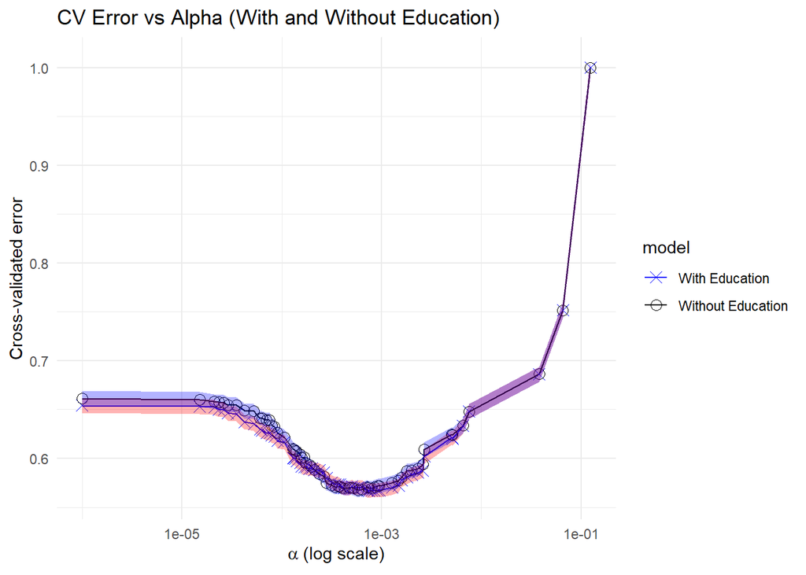

```r
# Create data frames from the cptable of both models
data_with_education <- data.frame(CP = cv_error_with_education$cptable[,"CP"],
                                  xerror = cv_error_with_education$cptable[,"xerror"],
                                  xstd = cv_error_with_education$cptable[,"xstd"])

data_no_education <- data.frame(CP = cv_error_no_education$cptable[,"CP"],
                                xerror = cv_error_no_education$cptable[,"xerror"],
                                xstd = cv_error_no_education$cptable[,"xstd"])

# Combine the data for both models, adding a column to distinguish between them
data_with_education$model <- "With Education"
data_no_education$model <- "Without Education"

combined_data <- rbind(
  data_with_education,
  data_no_education
)

# Plot the combined cross-validated error curves for both models
ggplot(combined_data, aes(x = CP, y = xerror, color = model, shape = model)) +
  geom_line() +
  geom_point(size = 3) +
  geom_ribbon(data = data_with_education, aes(x = CP, ymin = xerror - xstd, ymax = xerror + xstd),
              fill = "red", alpha = 0.3, inherit.aes = FALSE) +
  geom_ribbon(data = data_no_education, aes(x = CP, ymin = xerror - xstd, ymax = xerror + xstd),
              fill = "blue", alpha = 0.3, inherit.aes = FALSE) +
  scale_x_log10() +
  labs(title = "CV Error vs Alpha (With and Without Education)",
       x = expression(alpha ~ "(log scale)"),
       y = "Cross-validated error") +
  theme_minimal() +
  scale_shape_manual(values = c("With Education" = 4, "Without Education" = 1)) +  # 'x' for one, '.' for other
  scale_color_manual(values = c("With Education" = "blue", "Without Education" = "black"))
```

Since the best models with or without `education` perform similarly, we will not be very fussy about this in later sections.